# ANALISIS DESCRIPTIVO

David Sebastian Gonzalez

11/4/2021

# Introduccion

En este informe se va a hacer una analisis descritivo de los datos de moratalidad en ciudades de Estados Unidos en cual esta sujetos a factores como climaticos, sociales, contaminacion ambiental) el estudio se realizo hace 60 años al rededor de la epoca de los 60’s se van a aplicar pruebas de hipotesis, intervalos de confianza para que de tal forma en base a los datos que se estan examinando se haga una inferencia y sacar concluciones de la misma; De igual manera, se utilizaran grafica para que la interpretacion sea mas amena visualmente.

En EE.UU. de 1960 era una epoca en la que se esta viviendo una postguerra la cual tenia varias concecuencias como socioculturales, Uno de los movimientos sin violencia en los Estados Unidos buscaba resolver las ilegalidades constitucionales de los derechos civiles, especialmente la generalizada segregación racial, la antigua Segregación en la reconstrucción de las personas negras en el sur por los gobiernos dominados por gente blanca, y la constante discriminación racial en trabajos, vivienda y acceso a lugares públicos tanto en el norte como el sur de Estados Unidos. Con esto buscamos contextualizar algunas variables expuestas en la bas de datos de la tasa de mortalidad. Los datos incluyen mediciones de la tasa de mortalidad y variables explicativas (contaminación del aire, socioeconómicas y meteorológicas) para 60 ciudades de EE.UU. en 1960.

Fuente: McDonald, G.C. y Schwing, R.C. (1973) ‘Inestabilidades de regresión estimaciones que relacionan la contaminación del aire con la mortalidad’, Technometrics, vol.15, 463-482

Variables en orden:

- PREC Precipitación media anual en pulgadas.
- JANT Temperatura promedio de enero en grados F.
- JULT Lo mismo para julio
- OVR65 % de la población de 1960 de las áreas estadísticas metropolitanas estándar de 65 años o más.
- POPN Tamaño promedio del hogar
- EDUC Años escolares promedio completados por los mayores de 22
- HOUS % de viviendas sólidas y con todas las comodidades
- DENS Población por milla cuadrada en áreas urbanizadas, 1960
- NONW % de población no blanca en áreas urbanizadas, 1960
- WWDRK % empleado o empleada en ocupaciones de cuello blanco.
- POOR % de familias con ingresos menores a $3000
- HC Potencial relativo de contaminación por hidrocarburos
- NOX Lo mismo para los óxidos nítricos.
- SO@ Lo mismo para el dióxido de azufre
- HUMID % De humedad relativa promedio anual a las 1:00 pm
- MORT Tasa de mortalidad total ajustada por edad por 100.000

# Datos a explorador de la tasa de mortalidad de ciudades de Estados Unidos.

```
## # A tibble: 3 x 16
##    PREC  JANT  JULT OVR65  POPN  EDUC  HOUS  DENS  NONW WWDRK  POOR    HC   NOX
##   <dbl> <dbl> <dbl> <dbl> <dbl> <dbl> <dbl> <dbl> <dbl> <dbl> <dbl> <dbl> <dbl>
## 1    36    27    71   8.1  3.34  11.4  81.5  3243   8.8  42.6  11.7    21    15
## 2    35    23    72  11.1  3.14  11    78.8  4281   3.5  50.7  14.4     8    10
## 3    44    29    74  10.4  3.21   9.8  81.6  4260   0.8  39.4  12.4     6     6
## # ... with 3 more variables: `SO@` <dbl>, HUMID <dbl>, MORT <dbl>
```

## Resumen de los datos obtenidos de la tasa de mortalidad

Se hara un resumen de todas las variables para tener una la base del comportaiento de cada un de ellos, y asi poder saber que se puede emplear con las variables.

```r
datos%>%
  pivot_longer(c(PREC,JANT,JULT,OVR65,POPN,EDUC,HOUS,DENS,NONW,WWDRK,POOR,HC,NOX,`SO@`,HUMID, MORT),names_to="Medida",values_to="Valor") %>%
  group_by(Medida) %>%
  summarise_at(vars(Valor), listaFunciones) %>%
  flextable() %>%  fontsize(size=8,part="all") %>%
  set_caption("Resumen descritivo de la tasa de mortalidad")%>%
  autofit()
```

Resumen descritivo de la tasa de mortalidad

| Medida | mediaSd | medianaQ | asimetria | curtosis | min | max | n_valid |
| --- | --- | --- | --- | --- | --- | --- | --- |
| DENS | 3876.05 (1454.1) | 3567 (3104.25, 4519.75) | 1.37949291 | 3.59099308 | 1,441.000 | 9,699.000 | 60 |
| EDUC | 10.97 (0.85) | 11.05 (10.4, 11.5) | -0.22492857 | -0.75132313 | 9.000 | 12.300 | 60 |
| HC | 37.85 (91.98) | 14.5 (7, 30.25) | 5.59342236 | 34.68521516 | 1.000 | 648.000 | 60 |
| HOUS | 80.91 (5.14) | 81.15 (78.38, 83.6) | -0.41700236 | 0.38491867 | 66.800 | 90.700 | 60 |
| HUMID | 57.67 (5.37) | 57 (55, 60) | 0.23750821 | 4.28949827 | 38.000 | 73.000 | 60 |
| JANT | 33.98 (10.17) | 31.5 (27, 40) | 0.96071148 | 1.08782139 | 12.000 | 67.000 | 60 |
| JULT | 74.58 (4.76) | 74 (72, 77.25) | 0.13670577 | 0.01094463 | 63.000 | 85.000 | 60 |
| MORT | 940.36 (62.21) | 943.68 (898.37, 983.21) | 0.09841936 | 0.16332188 | 790.733 | 1,113.156 | 60 |
| NONW | 11.87 (8.92) | 10.4 (4.95, 15.65) | 1.13112835 | 0.93598493 | 0.800 | 38.500 | 60 |
| NOX | 22.65 (46.33) | 9 (4, 23.75) | 5.16555508 | 30.26372797 | 1.000 | 319.000 | 60 |
| OVR65 | 8.8 (1.46) | 9 (7.68, 9.7) | -0.03411600 | -0.60366352 | 5.600 | 11.800 | 60 |
| POOR | 14.37 (4.16) | 13.2 (12, 15.15) | 1.46352414 | 1.53144959 | 9.400 | 26.400 | 60 |
| POPN | 3.26 (0.14) | 3.26 (3.21, 3.36) | -0.48931622 | 0.04384506 | 2.920 | 3.530 | 60 |
| PREC | 37.37 (9.98) | 38 (32.75, 43.25) | -0.80218121 | 1.28361097 | 10.000 | 60.000 | 60 |
| SO@ | 53.77 (63.39) | 30 (11, 69) | 1.91179788 | 3.55159773 | 1.000 | 278.000 | 60 |
| WWDRK | 46.08 (4.61) | 45.5 (43.25, 49.52) | 0.09845541 | 0.55485125 | 33.800 | 59.700 | 60 |

## Intervalos de confianza

Se elaborara un intervalo de confianza con un nivel de significancia del 95% para cada variable con su media estimada el fin de proporciar mas informacion probabilistica de el comportamiento de los datos expuestos aqui.

```r
datos %>%
  select(PREC, JANT,JULT, OVR65, POPN,EDUC,HOUS,DENS,NONW,WWDRK,POOR,HC,NOX, `SO@`,HUMID,  MORT) %>%
  pivot_longer(1:16,names_to="Variable",values_to = "Valor") %>%
  group_by(Variable) %>%
  do(tidy(t.test(.$Valor, conf.level=0.95))) %>%
  do(formatInterval(.$estimate,.$conf.low,.$conf.high,digits=2,conf.level = 0.95))%>%
  flextable() %>%
  fontsize(size=14, part="all") %>%
  set_caption("Medias estimadas e Intervalos de Confianza al 95%") %>%
  autofit()
```

Medias estimadas e Intervalos de Confianza al 95%

| Variable | estimate | CI95% |
| --- | --- | --- |
| DENS | 3,876.05 | (3500.42, 4251.68) |
| EDUC | 10.97 | (10.75, 11.19) |
| HC | 37.85 | (14.09, 61.61) |
| HOUS | 80.91 | (79.59, 82.24) |
| HUMID | 57.67 | (56.28, 59.05) |
| JANT | 33.98 | (31.36, 36.61) |
| JULT | 74.58 | (73.35, 75.81) |
| MORT | 940.36 | (924.29, 956.43) |
| NONW | 11.87 | (9.57, 14.17) |
| NOX | 22.65 | (10.68, 34.62) |
| OVR65 | 8.80 | (8.42, 9.18) |
| POOR | 14.37 | (13.3, 15.45) |
| POPN | 3.26 | (3.23, 3.3) |
| PREC | 37.37 | (34.79, 39.95) |
| SO@ | 53.77 | (37.39, 70.14) |
| WWDRK | 46.08 | (44.89, 47.27) |

## Prueba de hipotesis

Se realizara ciertas pruebas de hipotesis a alguna variables con el proposito de identificar objetivos especificos direccionados a las preferencias del autor que analisa la base.

$H_1 < \pi_0$ Si se rechaza la hipotesis nula se afirmara que la ciudades no estan en riesgo de contaminacion por dioxido de azufre.

```r
datos %>%
  mutate(dioxido=ifelse(NOX>median(NOX),"Sí","No")) %>%
  tabyl(dioxido) %>%
  adorn_totals("row")
```

```
##  dioxido  n   percent
##       No 31 0.5166667
##       Sí 29 0.4833333
##    Total 60 1.0000000
```

```r
binom.test(29,60,p=0.5,alternative = "less")
```

```
##
##  Exact binomial test
##
## data:  29 and 60
## number of successes = 29, number of trials = 60, p-value = 0.4487
## alternative hypothesis: true probability of success is less than 0.5
## 95 percent confidence interval:
##  0.0000000 0.5965038
## sample estimates:
## probability of success
##              0.4833333
```

### Pobreza de familias en Estados Unidos en la epoca de los 60’s

Se hara una prueba de hipotesis con respecto a la variable “POOR” la cual nos indica el porcentaje de nivel de probleza en las ciudades de Estados Unidos queremos evidenciar la situacion socioeconomica de estas ciudades para poder saber si tienen una correlacion con la tasa de mortalidad.

¿Existe evidencia suficiente para afirmar que la proporcion de la probreza es mayor al 18% de las ciudades?

$H_0 \ge \pi_0$ la hipotesis nula es la pobreza es mayor que el 18% de las poblaciones de las ciudades de Estados unidos.

$H_1 < \pi_0$ hipotesis alternativa la pobreza de las familias es menor que el 18% de la poblacion de las ciudades de Estados Unidos

```r
datos %>%
  mutate(Pobreza=ifelse(POOR>15,"Sí","No")) %>%
  tabyl(Pobreza) %>%
  adorn_totals("row")
```

```
##  Pobreza  n   percent
##       No 44 0.7333333
##       Sí 16 0.2666667
##    Total 60 1.0000000
```

```r
binom.test(16,60,p=0.18,alternative = "less")
```

```
##
##  Exact binomial test
##
## data:  16 and 60
## number of successes = 16, number of trials = 60, p-value = 0.9672
## alternative hypothesis: true probability of success is less than 0.18
## 95 percent confidence interval:
##  0.0000000 0.3764289
## sample estimates:
## probability of success
##              0.2666667
```

### Graficas de las variables

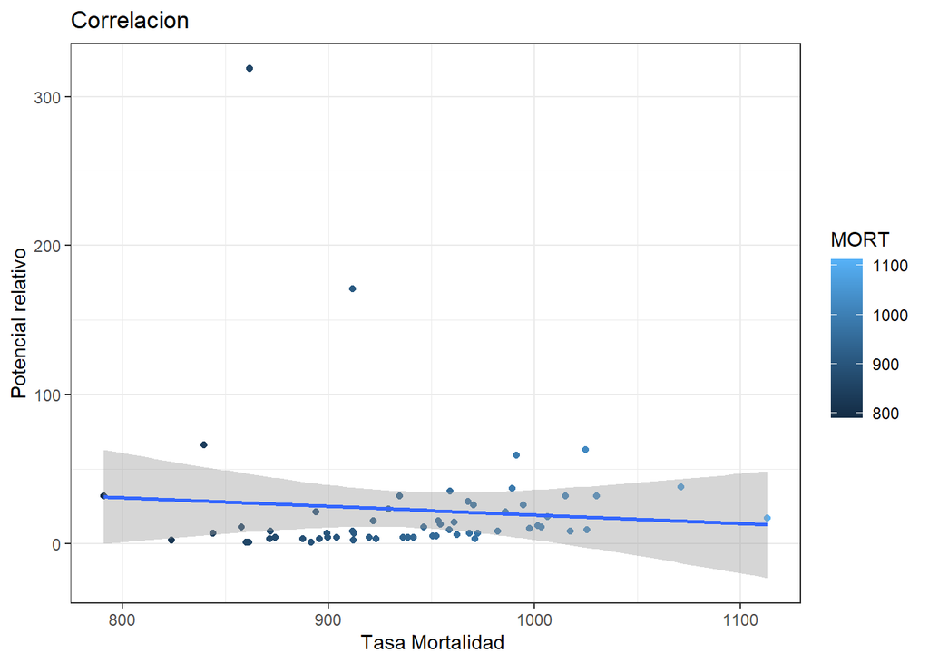

```r
datos%>%
  ggplot(aes(MORT,NOX,color=MORT)) +geom_point() +
  geom_smooth(method = "lm") +
  labs( y="Potencial relativo",x="Tasa Mortalidad ",title="Correlacion")+
  theme_bw()
```

#### MODELO LINEAL entre Tasa mortalidad y pobreza

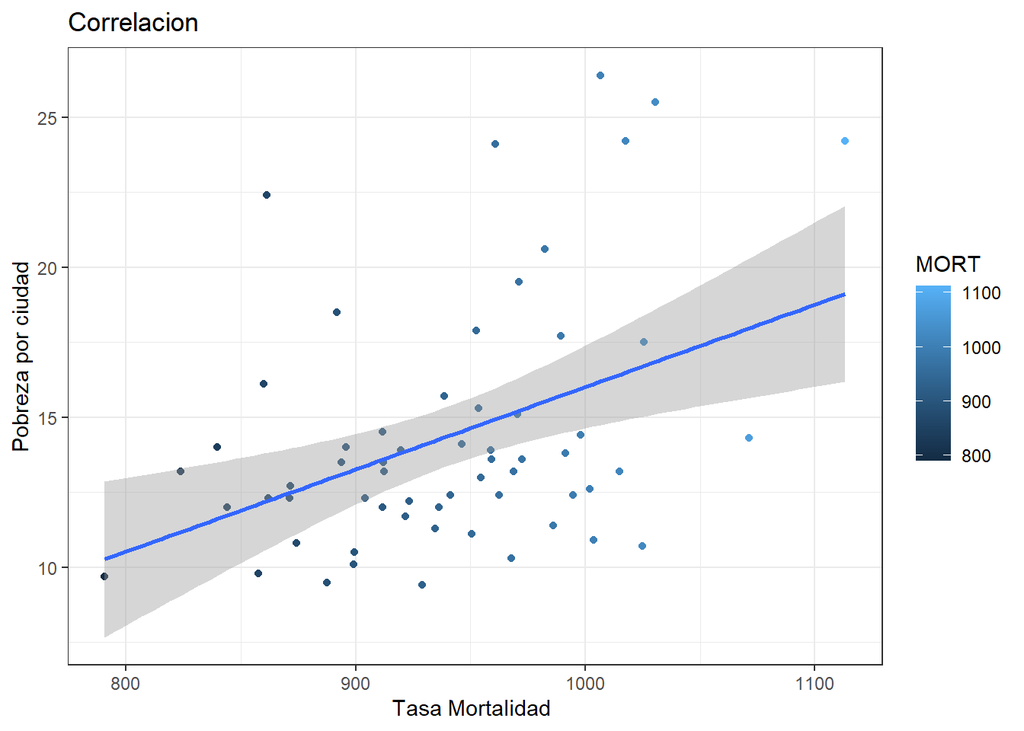

```r
datos%>%
  ggplot(aes(MORT,POOR,color=MORT)) +geom_point() +
  geom_smooth(method = "lm") +
  labs( y="Pobreza por ciudad",x="Tasa Mortalidad ",title="Correlacion")+
  theme_bw()
```